# Risk Factor Analysis

## Outcome Variable

**Outcome Variable:** wast_rec90d

## Predictor Variables

**Intervention Variable:** birthwt

**Adjustment Set:**

- arm
- sex
- W_mage
- meducyrs
- feducyrs
- vagbrth
- single
- brthmon
- W_parity
- delta_W_mage
- delta_meducyrs
- delta_feducyrs
- delta_vagbrth
- delta_single
- delta_brthmon
- delta_W_parity

## Stratifying Variables

The analysis was stratified on these variable(s):

- agecat
- studyid
- country

## Data Summary

| agecat | studyid | country | birthwt | wast_rec90d | n_cell | n |
| --- | --- | --- | --- | --- | --- | --- |
| 0-24 months | CMC-V-BCS-2002 | INDIA | Normal or high birthweight | 0 | 96 | 318 |
| 0-24 months | CMC-V-BCS-2002 | INDIA | Normal or high birthweight | 1 | 168 | 318 |
| 0-24 months | CMC-V-BCS-2002 | INDIA | Low birthweight | 0 | 23 | 318 |
| 0-24 months | CMC-V-BCS-2002 | INDIA | Low birthweight | 1 | 31 | 318 |
| 0-24 months | CMIN | BANGLADESH | Normal or high birthweight | 0 | 2 | 12 |
| 0-24 months | CMIN | BANGLADESH | Normal or high birthweight | 1 | 5 | 12 |
| 0-24 months | CMIN | BANGLADESH | Low birthweight | 0 | 3 | 12 |
| 0-24 months | CMIN | BANGLADESH | Low birthweight | 1 | 2 | 12 |
| 0-24 months | COHORTS | GUATEMALA | Normal or high birthweight | 0 | 134 | 320 |
| 0-24 months | COHORTS | GUATEMALA | Normal or high birthweight | 1 | 139 | 320 |
| 0-24 months | COHORTS | GUATEMALA | Low birthweight | 0 | 21 | 320 |
| 0-24 months | COHORTS | GUATEMALA | Low birthweight | 1 | 26 | 320 |
| 0-24 months | COHORTS | INDIA | Normal or high birthweight | 0 | 1227 | 2516 |
| 0-24 months | COHORTS | INDIA | Normal or high birthweight | 1 | 343 | 2516 |
| 0-24 months | COHORTS | INDIA | Low birthweight | 0 | 645 | 2516 |
| 0-24 months | COHORTS | INDIA | Low birthweight | 1 | 301 | 2516 |
| 0-24 months | COHORTS | PHILIPPINES | Normal or high birthweight | 0 | 524 | 1664 |
| 0-24 months | COHORTS | PHILIPPINES | Normal or high birthweight | 1 | 830 | 1664 |
| 0-24 months | COHORTS | PHILIPPINES | Low birthweight | 0 | 130 | 1664 |
| 0-24 months | COHORTS | PHILIPPINES | Low birthweight | 1 | 180 | 1664 |
| 0-24 months | EE | PAKISTAN | Normal or high birthweight | 0 | 93 | 322 |
| 0-24 months | EE | PAKISTAN | Normal or high birthweight | 1 | 94 | 322 |
| 0-24 months | EE | PAKISTAN | Low birthweight | 0 | 67 | 322 |
| 0-24 months | EE | PAKISTAN | Low birthweight | 1 | 68 | 322 |
| 0-24 months | GMS-Nepal | NEPAL | Normal or high birthweight | 0 | 166 | 641 |
| 0-24 months | GMS-Nepal | NEPAL | Normal or high birthweight | 1 | 219 | 641 |
| 0-24 months | GMS-Nepal | NEPAL | Low birthweight | 0 | 128 | 641 |
| 0-24 months | GMS-Nepal | NEPAL | Low birthweight | 1 | 128 | 641 |
| 0-24 months | IRC | INDIA | Normal or high birthweight | 0 | 115 | 390 |
| 0-24 months | IRC | INDIA | Normal or high birthweight | 1 | 174 | 390 |

[output cut: 282 more lines]

The following strata were considered:

- agecat: 0-24 months, studyid: CMC-V-BCS-2002, country: INDIA
- agecat: 0-24 months, studyid: CMIN, country: BANGLADESH
- agecat: 0-24 months, studyid: COHORTS, country: GUATEMALA
- agecat: 0-24 months, studyid: COHORTS, country: INDIA
- agecat: 0-24 months, studyid: COHORTS, country: PHILIPPINES
- agecat: 0-24 months, studyid: EE, country: PAKISTAN
- agecat: 0-24 months, studyid: GMS-Nepal, country: NEPAL
- agecat: 0-24 months, studyid: IRC, country: INDIA
- agecat: 0-24 months, studyid: JiVitA-3, country: BANGLADESH
- agecat: 0-24 months, studyid: JiVitA-4, country: BANGLADESH
- agecat: 0-24 months, studyid: Keneba, country: GAMBIA
- agecat: 0-24 months, studyid: MAL-ED, country: BANGLADESH
- agecat: 0-24 months, studyid: MAL-ED, country: BRAZIL
- agecat: 0-24 months, studyid: MAL-ED, country: INDIA
- agecat: 0-24 months, studyid: MAL-ED, country: NEPAL
- agecat: 0-24 months, studyid: MAL-ED, country: PERU
- agecat: 0-24 months, studyid: MAL-ED, country: SOUTH AFRICA
- agecat: 0-24 months, studyid: MAL-ED, country: TANZANIA, UNITED REPUBLIC OF
- agecat: 0-24 months, studyid: NIH-Birth, country: BANGLADESH
- agecat: 0-24 months, studyid: NIH-Crypto, country: BANGLADESH
- agecat: 0-24 months, studyid: PROBIT, country: BELARUS
- agecat: 0-24 months, studyid: PROVIDE, country: BANGLADESH
- agecat: 0-24 months, studyid: ResPak, country: PAKISTAN
- agecat: 0-24 months, studyid: SAS-CompFeed, country: INDIA
- agecat: 0-24 months, studyid: TanzaniaChild2, country: TANZANIA, UNITED REPUBLIC OF
- agecat: 0-24 months, studyid: ZVITAMBO, country: ZIMBABWE
- agecat: 0-6 months, studyid: CMC-V-BCS-2002, country: INDIA
- agecat: 0-6 months, studyid: CMIN, country: BANGLADESH
- agecat: 0-6 months, studyid: COHORTS, country: GUATEMALA
- agecat: 0-6 months, studyid: COHORTS, country: INDIA
- agecat: 0-6 months, studyid: COHORTS, country: PHILIPPINES
- agecat: 0-6 months, studyid: EE, country: PAKISTAN
- agecat: 0-6 months, studyid: GMS-Nepal, country: NEPAL
- agecat: 0-6 months, studyid: IRC, country: INDIA
- agecat: 0-6 months, studyid: JiVitA-3, country: BANGLADESH
- agecat: 0-6 months, studyid: JiVitA-4, country: BANGLADESH
- agecat: 0-6 months, studyid: Keneba, country: GAMBIA
- agecat: 0-6 months, studyid: MAL-ED, country: BANGLADESH
- agecat: 0-6 months, studyid: MAL-ED, country: BRAZIL
- agecat: 0-6 months, studyid: MAL-ED, country: INDIA
- agecat: 0-6 months, studyid: MAL-ED, country: NEPAL
- agecat: 0-6 months, studyid: MAL-ED, country: PERU
- agecat: 0-6 months, studyid: MAL-ED, country: SOUTH AFRICA
- agecat: 0-6 months, studyid: MAL-ED, country: TANZANIA, UNITED REPUBLIC OF
- agecat: 0-6 months, studyid: NIH-Birth, country: BANGLADESH
- agecat: 0-6 months, studyid: NIH-Crypto, country: BANGLADESH
- agecat: 0-6 months, studyid: PROBIT, country: BELARUS
- agecat: 0-6 months, studyid: PROVIDE, country: BANGLADESH
- agecat: 0-6 months, studyid: ResPak, country: PAKISTAN
- agecat: 0-6 months, studyid: SAS-CompFeed, country: INDIA
- agecat: 0-6 months, studyid: TanzaniaChild2, country: TANZANIA, UNITED REPUBLIC OF
- agecat: 0-6 months, studyid: ZVITAMBO, country: ZIMBABWE
- agecat: 6-24 months, studyid: CMC-V-BCS-2002, country: INDIA
- agecat: 6-24 months, studyid: CMIN, country: BANGLADESH
- agecat: 6-24 months, studyid: COHORTS, country: GUATEMALA
- agecat: 6-24 months, studyid: COHORTS, country: INDIA
- agecat: 6-24 months, studyid: COHORTS, country: PHILIPPINES
- agecat: 6-24 months, studyid: EE, country: PAKISTAN
- agecat: 6-24 months, studyid: GMS-Nepal, country: NEPAL
- agecat: 6-24 months, studyid: IRC, country: INDIA
- agecat: 6-24 months, studyid: JiVitA-3, country: BANGLADESH
- agecat: 6-24 months, studyid: JiVitA-4, country: BANGLADESH
- agecat: 6-24 months, studyid: Keneba, country: GAMBIA
- agecat: 6-24 months, studyid: MAL-ED, country: BANGLADESH
- agecat: 6-24 months, studyid: MAL-ED, country: BRAZIL
- agecat: 6-24 months, studyid: MAL-ED, country: INDIA
- agecat: 6-24 months, studyid: MAL-ED, country: NEPAL
- agecat: 6-24 months, studyid: MAL-ED, country: PERU
- agecat: 6-24 months, studyid: MAL-ED, country: SOUTH AFRICA
- agecat: 6-24 months, studyid: MAL-ED, country: TANZANIA, UNITED REPUBLIC OF
- agecat: 6-24 months, studyid: NIH-Birth, country: BANGLADESH
- agecat: 6-24 months, studyid: NIH-Crypto, country: BANGLADESH
- agecat: 6-24 months, studyid: PROBIT, country: BELARUS
- agecat: 6-24 months, studyid: PROVIDE, country: BANGLADESH
- agecat: 6-24 months, studyid: ResPak, country: PAKISTAN
- agecat: 6-24 months, studyid: SAS-CompFeed, country: INDIA
- agecat: 6-24 months, studyid: TanzaniaChild2, country: TANZANIA, UNITED REPUBLIC OF
- agecat: 6-24 months, studyid: ZVITAMBO, country: ZIMBABWE

### Dropped Strata

Some strata were dropped due to rare outcomes:

- agecat: 0-24 months, studyid: CMIN, country: BANGLADESH
- agecat: 0-24 months, studyid: MAL-ED, country: BRAZIL
- agecat: 0-24 months, studyid: MAL-ED, country: NEPAL
- agecat: 0-24 months, studyid: MAL-ED, country: PERU
- agecat: 0-24 months, studyid: MAL-ED, country: SOUTH AFRICA
- agecat: 0-24 months, studyid: MAL-ED, country: TANZANIA, UNITED REPUBLIC OF
- agecat: 0-24 months, studyid: PROBIT, country: BELARUS
- agecat: 0-24 months, studyid: ResPak, country: PAKISTAN
- agecat: 0-6 months, studyid: CMIN, country: BANGLADESH
- agecat: 0-6 months, studyid: MAL-ED, country: BANGLADESH
- agecat: 0-6 months, studyid: MAL-ED, country: BRAZIL
- agecat: 0-6 months, studyid: MAL-ED, country: NEPAL
- agecat: 0-6 months, studyid: MAL-ED, country: PERU
- agecat: 0-6 months, studyid: MAL-ED, country: SOUTH AFRICA
- agecat: 0-6 months, studyid: MAL-ED, country: TANZANIA, UNITED REPUBLIC OF
- agecat: 0-6 months, studyid: PROBIT, country: BELARUS
- agecat: 0-6 months, studyid: ResPak, country: PAKISTAN
- agecat: 6-24 months, studyid: CMIN, country: BANGLADESH
- agecat: 6-24 months, studyid: COHORTS, country: GUATEMALA
- agecat: 6-24 months, studyid: COHORTS, country: INDIA
- agecat: 6-24 months, studyid: JiVitA-3, country: BANGLADESH
- agecat: 6-24 months, studyid: MAL-ED, country: BRAZIL
- agecat: 6-24 months, studyid: MAL-ED, country: NEPAL
- agecat: 6-24 months, studyid: MAL-ED, country: PERU
- agecat: 6-24 months, studyid: MAL-ED, country: SOUTH AFRICA
- agecat: 6-24 months, studyid: MAL-ED, country: TANZANIA, UNITED REPUBLIC OF
- agecat: 6-24 months, studyid: NIH-Crypto, country: BANGLADESH
- agecat: 6-24 months, studyid: PROBIT, country: BELARUS
- agecat: 6-24 months, studyid: ResPak, country: PAKISTAN

## Methods Detail

We’re interested in the causal parameters $E[Y_a]$ for all values of $a \in \mathcal{A}$. These parameters represent the mean outcome if, possibly contrary to fact, we intervened to set all units to have $A=a$. Under the randomization and positivity assumptions, these are identified by the statistical parameters $\psi_a=E_W[E_{Y|A,W}(Y|A=a,W)]$. In addition, we’re interested in the mean of $Y$, $E[Y]$ under no intervention (the observed mean). We will estimate these parameters by using SuperLearner to fit the relevant likelihood factors – $E_{Y|A,W}(Y|A=a,W)$ and $p(A=a|W)$, and then updating our likelihood fit using a joint TMLE.

For unadjusted analyses ($W=\{\}$), initial likelihoods were estimated using Lrnr_glm to estimate the simple $E(Y|A)$ and Lrnr_mean to estimate $p(A)$. For adjusted analyses, a small library containing Lrnr_glmnet, Lrnr_xgboost, and Lrnr_mean was used.

Having estimated these parameters, we will then use the delta method to estimate relative risks and attributable risks relative to a prespecified baseline level of $A$.

# Results Detail

## Results Plots

[figure not shown]

[figure not shown]

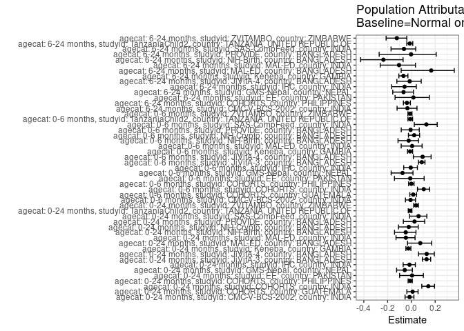

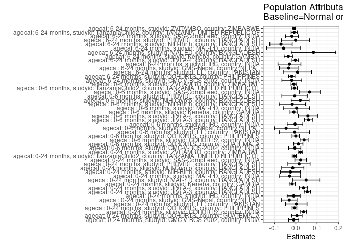

## Results Table

### Parameter: TSM

| agecat | studyid | country | intervention_level | baseline_level | estimate | ci_lower | ci_upper |
| --- | --- | --- | --- | --- | --- | --- | --- |
| 0-24 months | CMC-V-BCS-2002 | INDIA | Normal or high birthweight | NA | 0.6354036 | 0.5719755 | 0.6988318 |
| 0-24 months | CMC-V-BCS-2002 | INDIA | Low birthweight | NA | 0.5853120 | 0.4626622 | 0.7079617 |
| 0-24 months | COHORTS | GUATEMALA | Normal or high birthweight | NA | 0.5103859 | 0.4499142 | 0.5708576 |
| 0-24 months | COHORTS | GUATEMALA | Low birthweight | NA | 0.5447858 | 0.3909813 | 0.6985902 |
| 0-24 months | COHORTS | INDIA | Normal or high birthweight | NA | 0.2194901 | 0.1985122 | 0.2404681 |
| 0-24 months | COHORTS | INDIA | Low birthweight | NA | 0.3178391 | 0.2886809 | 0.3469972 |
| 0-24 months | COHORTS | PHILIPPINES | Normal or high birthweight | NA | 0.6129253 | 0.5850393 | 0.6408113 |
| 0-24 months | COHORTS | PHILIPPINES | Low birthweight | NA | 0.5818233 | 0.5303486 | 0.6332980 |
| 0-24 months | EE | PAKISTAN | Normal or high birthweight | NA | 0.5002639 | 0.4203099 | 0.5802178 |
| 0-24 months | EE | PAKISTAN | Low birthweight | NA | 0.5085429 | 0.4193231 | 0.5977627 |
| 0-24 months | GMS-Nepal | NEPAL | Normal or high birthweight | NA | 0.5716010 | 0.5156576 | 0.6275445 |
| 0-24 months | GMS-Nepal | NEPAL | Low birthweight | NA | 0.5010111 | 0.4345819 | 0.5674403 |
| 0-24 months | IRC | INDIA | Normal or high birthweight | NA | 0.5996224 | 0.5372709 | 0.6619739 |
| 0-24 months | IRC | INDIA | Low birthweight | NA | 0.5407875 | 0.4436295 | 0.6379455 |
| 0-24 months | JiVitA-3 | BANGLADESH | Normal or high birthweight | NA | 0.3689653 | 0.3501082 | 0.3878225 |
| 0-24 months | JiVitA-3 | BANGLADESH | Low birthweight | NA | 0.4619185 | 0.4461859 | 0.4776510 |
| 0-24 months | JiVitA-4 | BANGLADESH | Normal or high birthweight | NA | 0.2425223 | 0.2143337 | 0.2707109 |
| 0-24 months | JiVitA-4 | BANGLADESH | Low birthweight | NA | 0.3275573 | 0.2947627 | 0.3603519 |
| 0-24 months | Keneba | GAMBIA | Normal or high birthweight | NA | 0.6773325 | 0.6455645 | 0.7091005 |
| 0-24 months | Keneba | GAMBIA | Low birthweight | NA | 0.5921275 | 0.5318989 | 0.6523561 |
| 0-24 months | MAL-ED | BANGLADESH | Normal or high birthweight | NA | 0.5991153 | 0.4769736 | 0.7212570 |
| 0-24 months | MAL-ED | BANGLADESH | Low birthweight | NA | 0.7280145 | 0.6149006 | 0.8411284 |
| 0-24 months | MAL-ED | INDIA | Normal or high birthweight | NA | 0.6429241 | 0.5447330 | 0.7411152 |
| 0-24 months | MAL-ED | INDIA | Low birthweight | NA | 0.5392874 | 0.3817073 | 0.6968675 |
| 0-24 months | NIH-Birth | BANGLADESH | Normal or high birthweight | NA | 0.5418919 | 0.4685276 | 0.6152562 |
| 0-24 months | NIH-Birth | BANGLADESH | Low birthweight | NA | 0.4854417 | 0.4116144 | 0.5592689 |
| 0-24 months | NIH-Crypto | BANGLADESH | Normal or high birthweight | NA | 0.6364092 | 0.5540462 | 0.7187723 |
| 0-24 months | NIH-Crypto | BANGLADESH | Low birthweight | NA | 0.6259120 | 0.5557484 | 0.6960756 |
| 0-24 months | PROVIDE | BANGLADESH | Normal or high birthweight | NA | 0.5658783 | 0.4856236 | 0.6461330 |
| 0-24 months | PROVIDE | BANGLADESH | Low birthweight | NA | 0.6149086 | 0.5352233 | 0.6945940 |

[output cut: 68 more lines]

### Parameter: E(Y)

| agecat | studyid | country | intervention_level | baseline_level | estimate | ci_lower | ci_upper |
| --- | --- | --- | --- | --- | --- | --- | --- |
| 0-24 months | CMC-V-BCS-2002 | INDIA | NA | NA | 0.6257862 | 0.5690209 | 0.6825515 |
| 0-24 months | COHORTS | GUATEMALA | NA | NA | 0.5156250 | 0.4594779 | 0.5717721 |
| 0-24 months | COHORTS | INDIA | NA | NA | 0.2559618 | 0.2388022 | 0.2731215 |
| 0-24 months | COHORTS | PHILIPPINES | NA | NA | 0.6069712 | 0.5823178 | 0.6316245 |
| 0-24 months | EE | PAKISTAN | NA | NA | 0.5031056 | 0.4439609 | 0.5622503 |
| 0-24 months | GMS-Nepal | NEPAL | NA | NA | 0.5413417 | 0.4990070 | 0.5836763 |
| 0-24 months | IRC | INDIA | NA | NA | 0.5897436 | 0.5370721 | 0.6424150 |
| 0-24 months | JiVitA-3 | BANGLADESH | NA | NA | 0.4230769 | 0.4110235 | 0.4351303 |
| 0-24 months | JiVitA-4 | BANGLADESH | NA | NA | 0.2783678 | 0.2569102 | 0.2998254 |
| 0-24 months | Keneba | GAMBIA | NA | NA | 0.6606557 | 0.6326585 | 0.6886530 |
| 0-24 months | MAL-ED | BANGLADESH | NA | NA | 0.6475410 | 0.5607680 | 0.7343140 |
| 0-24 months | MAL-ED | INDIA | NA | NA | 0.6144578 | 0.5320591 | 0.6968566 |
| 0-24 months | NIH-Birth | BANGLADESH | NA | NA | 0.5171569 | 0.4657250 | 0.5685888 |
| 0-24 months | NIH-Crypto | BANGLADESH | NA | NA | 0.6225806 | 0.5684562 | 0.6767051 |
| 0-24 months | PROVIDE | BANGLADESH | NA | NA | 0.5811688 | 0.5245443 | 0.6377934 |
| 0-24 months | SAS-CompFeed | INDIA | NA | NA | 0.3822441 | 0.3470621 | 0.4174262 |
| 0-24 months | TanzaniaChild2 | TANZANIA, UNITED REPUBLIC OF | NA | NA | 0.6258890 | 0.5879514 | 0.6638267 |
| 0-24 months | ZVITAMBO | ZIMBABWE | NA | NA | 0.5443459 | 0.5279394 | 0.5607524 |
| 0-6 months | CMC-V-BCS-2002 | INDIA | NA | NA | 0.6700508 | 0.6033656 | 0.7367359 |
| 0-6 months | COHORTS | GUATEMALA | NA | NA | 0.7619048 | 0.7043195 | 0.8194900 |
| 0-6 months | COHORTS | INDIA | NA | NA | 0.3748545 | 0.3519572 | 0.3977518 |
| 0-6 months | COHORTS | PHILIPPINES | NA | NA | 0.7372654 | 0.7055895 | 0.7689413 |
| 0-6 months | EE | PAKISTAN | NA | NA | 0.5634921 | 0.4761607 | 0.6508235 |
| 0-6 months | GMS-Nepal | NEPAL | NA | NA | 0.6045627 | 0.5449300 | 0.6641955 |
| 0-6 months | IRC | INDIA | NA | NA | 0.6355932 | 0.5725724 | 0.6986140 |
| 0-6 months | JiVitA-3 | BANGLADESH | NA | NA | 0.6804689 | 0.6660338 | 0.6949041 |
| 0-6 months | JiVitA-4 | BANGLADESH | NA | NA | 0.6058824 | 0.5634305 | 0.6483342 |
| 0-6 months | Keneba | GAMBIA | NA | NA | 0.8256228 | 0.7953169 | 0.8559287 |
| 0-6 months | MAL-ED | INDIA | NA | NA | 0.6875000 | 0.5835705 | 0.7914295 |
| 0-6 months | NIH-Birth | BANGLADESH | NA | NA | 0.7142857 | 0.6541352 | 0.7744362 |
| 0-6 months | NIH-Crypto | BANGLADESH | NA | NA | 0.8934010 | 0.8497799 | 0.9370221 |
| 0-6 months | PROVIDE | BANGLADESH | NA | NA | 0.7837838 | 0.7252863 | 0.8422812 |
| 0-6 months | SAS-CompFeed | INDIA | NA | NA | 0.5147059 | 0.4610948 | 0.5683169 |
| 0-6 months | TanzaniaChild2 | TANZANIA, UNITED REPUBLIC OF | NA | NA | 0.7014925 | 0.6517566 | 0.7512285 |
| 0-6 months | ZVITAMBO | ZIMBABWE | NA | NA | 0.7481128 | 0.7311662 | 0.7650594 |
| 6-24 months | CMC-V-BCS-2002 | INDIA | NA | NA | 0.5537190 | 0.4599630 | 0.6474751 |
| 6-24 months | COHORTS | PHILIPPINES | NA | NA | 0.5010893 | 0.4669869 | 0.5351918 |
| 6-24 months | EE | PAKISTAN | NA | NA | 0.4642857 | 0.3910729 | 0.5374985 |
| 6-24 months | GMS-Nepal | NEPAL | NA | NA | 0.4973545 | 0.4426760 | 0.5520330 |
| 6-24 months | IRC | INDIA | NA | NA | 0.5194805 | 0.4352979 | 0.6036631 |
| 6-24 months | JiVitA-4 | BANGLADESH | NA | NA | 0.1477717 | 0.1285384 | 0.1670050 |
| 6-24 months | Keneba | GAMBIA | NA | NA | 0.5197568 | 0.4787855 | 0.5607282 |
| 6-24 months | MAL-ED | BANGLADESH | NA | NA | 0.5000000 | 0.3680930 | 0.6319070 |
| 6-24 months | MAL-ED | INDIA | NA | NA | 0.5465116 | 0.4258714 | 0.6671519 |
| 6-24 months | NIH-Birth | BANGLADESH | NA | NA | 0.2931937 | 0.2273732 | 0.3590142 |
| 6-24 months | PROVIDE | BANGLADESH | NA | NA | 0.2764228 | 0.1950773 | 0.3577682 |
| 6-24 months | SAS-CompFeed | INDIA | NA | NA | 0.2866242 | 0.2446853 | 0.3285631 |
| 6-24 months | TanzaniaChild2 | TANZANIA, UNITED REPUBLIC OF | NA | NA | 0.5570652 | 0.5044805 | 0.6096499 |
| 6-24 months | ZVITAMBO | ZIMBABWE | NA | NA | 0.0742438 | 0.0587565 | 0.0897311 |

### Parameter: RR

| agecat | studyid | country | intervention_level | baseline_level | estimate | ci_lower | ci_upper |
| --- | --- | --- | --- | --- | --- | --- | --- |
| 0-24 months | CMC-V-BCS-2002 | INDIA | Normal or high birthweight | Normal or high birthweight | 1.0000000 | 1.0000000 | 1.0000000 |
| 0-24 months | CMC-V-BCS-2002 | INDIA | Low birthweight | Normal or high birthweight | 0.9211656 | 0.7310661 | 1.1606968 |
| 0-24 months | COHORTS | GUATEMALA | Normal or high birthweight | Normal or high birthweight | 1.0000000 | 1.0000000 | 1.0000000 |
| 0-24 months | COHORTS | GUATEMALA | Low birthweight | Normal or high birthweight | 1.0673997 | 0.7851750 | 1.4510677 |
| 0-24 months | COHORTS | INDIA | Normal or high birthweight | Normal or high birthweight | 1.0000000 | 1.0000000 | 1.0000000 |
| 0-24 months | COHORTS | INDIA | Low birthweight | Normal or high birthweight | 1.4480792 | 1.2686057 | 1.6529434 |
| 0-24 months | COHORTS | PHILIPPINES | Normal or high birthweight | Normal or high birthweight | 1.0000000 | 1.0000000 | 1.0000000 |
| 0-24 months | COHORTS | PHILIPPINES | Low birthweight | Normal or high birthweight | 0.9492565 | 0.8595860 | 1.0482813 |
| 0-24 months | EE | PAKISTAN | Normal or high birthweight | Normal or high birthweight | 1.0000000 | 1.0000000 | 1.0000000 |
| 0-24 months | EE | PAKISTAN | Low birthweight | Normal or high birthweight | 1.0165493 | 0.8018901 | 1.2886711 |
| 0-24 months | GMS-Nepal | NEPAL | Normal or high birthweight | Normal or high birthweight | 1.0000000 | 1.0000000 | 1.0000000 |
| 0-24 months | GMS-Nepal | NEPAL | Low birthweight | Normal or high birthweight | 0.8765049 | 0.7431905 | 1.0337334 |
| 0-24 months | IRC | INDIA | Normal or high birthweight | Normal or high birthweight | 1.0000000 | 1.0000000 | 1.0000000 |
| 0-24 months | IRC | INDIA | Low birthweight | Normal or high birthweight | 0.9018801 | 0.7326990 | 1.1101253 |
| 0-24 months | JiVitA-3 | BANGLADESH | Normal or high birthweight | Normal or high birthweight | 1.0000000 | 1.0000000 | 1.0000000 |
| 0-24 months | JiVitA-3 | BANGLADESH | Low birthweight | Normal or high birthweight | 1.2519292 | 1.1775175 | 1.3310433 |
| 0-24 months | JiVitA-4 | BANGLADESH | Normal or high birthweight | Normal or high birthweight | 1.0000000 | 1.0000000 | 1.0000000 |
| 0-24 months | JiVitA-4 | BANGLADESH | Low birthweight | Normal or high birthweight | 1.3506274 | 1.1587114 | 1.5743302 |
| 0-24 months | Keneba | GAMBIA | Normal or high birthweight | Normal or high birthweight | 1.0000000 | 1.0000000 | 1.0000000 |
| 0-24 months | Keneba | GAMBIA | Low birthweight | Normal or high birthweight | 0.8742051 | 0.7818183 | 0.9775092 |
| 0-24 months | MAL-ED | BANGLADESH | Normal or high birthweight | Normal or high birthweight | 1.0000000 | 1.0000000 | 1.0000000 |
| 0-24 months | MAL-ED | BANGLADESH | Low birthweight | Normal or high birthweight | 1.2151492 | 0.9392342 | 1.5721185 |
| 0-24 months | MAL-ED | INDIA | Normal or high birthweight | Normal or high birthweight | 1.0000000 | 1.0000000 | 1.0000000 |
| 0-24 months | MAL-ED | INDIA | Low birthweight | Normal or high birthweight | 0.8388042 | 0.6026074 | 1.1675802 |
| 0-24 months | NIH-Birth | BANGLADESH | Normal or high birthweight | Normal or high birthweight | 1.0000000 | 1.0000000 | 1.0000000 |
| 0-24 months | NIH-Birth | BANGLADESH | Low birthweight | Normal or high birthweight | 0.8958275 | 0.7307732 | 1.0981613 |
| 0-24 months | NIH-Crypto | BANGLADESH | Normal or high birthweight | Normal or high birthweight | 1.0000000 | 1.0000000 | 1.0000000 |
| 0-24 months | NIH-Crypto | BANGLADESH | Low birthweight | Normal or high birthweight | 0.9835055 | 0.8285516 | 1.1674387 |
| 0-24 months | PROVIDE | BANGLADESH | Normal or high birthweight | Normal or high birthweight | 1.0000000 | 1.0000000 | 1.0000000 |
| 0-24 months | PROVIDE | BANGLADESH | Low birthweight | Normal or high birthweight | 1.0866446 | 0.8963163 | 1.3173882 |

[output cut: 68 more lines]

### Parameter: PAR

| agecat | studyid | country | intervention_level | baseline_level | estimate | ci_lower | ci_upper |
| --- | --- | --- | --- | --- | --- | --- | --- |
| 0-24 months | CMC-V-BCS-2002 | INDIA | Normal or high birthweight | NA | -0.0096175 | -0.0330070 | 0.0137720 |
| 0-24 months | COHORTS | GUATEMALA | Normal or high birthweight | NA | 0.0052391 | -0.0190426 | 0.0295207 |
| 0-24 months | COHORTS | INDIA | Normal or high birthweight | NA | 0.0364717 | 0.0228752 | 0.0500683 |
| 0-24 months | COHORTS | PHILIPPINES | Normal or high birthweight | NA | -0.0059541 | -0.0166967 | 0.0047885 |
| 0-24 months | EE | PAKISTAN | Normal or high birthweight | NA | 0.0028417 | -0.0473126 | 0.0529960 |
| 0-24 months | GMS-Nepal | NEPAL | Normal or high birthweight | NA | -0.0302594 | -0.0660332 | 0.0055145 |
| 0-24 months | IRC | INDIA | Normal or high birthweight | NA | -0.0098788 | -0.0401427 | 0.0203850 |
| 0-24 months | JiVitA-3 | BANGLADESH | Normal or high birthweight | NA | 0.0541116 | 0.0394113 | 0.0688119 |
| 0-24 months | JiVitA-4 | BANGLADESH | Normal or high birthweight | NA | 0.0358455 | 0.0174819 | 0.0542091 |
| 0-24 months | Keneba | GAMBIA | Normal or high birthweight | NA | -0.0166767 | -0.0304815 | -0.0028719 |
| 0-24 months | MAL-ED | BANGLADESH | Normal or high birthweight | NA | 0.0484257 | -0.0151190 | 0.1119703 |
| 0-24 months | MAL-ED | INDIA | Normal or high birthweight | NA | -0.0284662 | -0.0776826 | 0.0207501 |
| 0-24 months | NIH-Birth | BANGLADESH | Normal or high birthweight | NA | -0.0247351 | -0.0715011 | 0.0220310 |
| 0-24 months | NIH-Crypto | BANGLADESH | Normal or high birthweight | NA | -0.0138286 | -0.0656216 | 0.0379644 |
| 0-24 months | PROVIDE | BANGLADESH | Normal or high birthweight | NA | 0.0152905 | -0.0367140 | 0.0672950 |
| 0-24 months | SAS-CompFeed | INDIA | Normal or high birthweight | NA | 0.0229373 | -0.0045867 | 0.0504612 |
| 0-24 months | TanzaniaChild2 | TANZANIA, UNITED REPUBLIC OF | Normal or high birthweight | NA | -0.0067527 | -0.0163964 | 0.0028910 |
| 0-24 months | ZVITAMBO | ZIMBABWE | Normal or high birthweight | NA | 0.0213516 | 0.0104551 | 0.0322481 |
| 0-6 months | CMC-V-BCS-2002 | INDIA | Normal or high birthweight | NA | -0.0046650 | -0.0329855 | 0.0236555 |
| 0-6 months | COHORTS | GUATEMALA | Normal or high birthweight | NA | 0.0119048 | -0.0096709 | 0.0334804 |
| 0-6 months | COHORTS | INDIA | Normal or high birthweight | NA | 0.0388927 | 0.0197163 | 0.0580691 |
| 0-6 months | COHORTS | PHILIPPINES | Normal or high birthweight | NA | -0.0002132 | -0.0170553 | 0.0166289 |
| 0-6 months | EE | PAKISTAN | Normal or high birthweight | NA | -0.0054978 | -0.0756510 | 0.0646555 |
| 0-6 months | GMS-Nepal | NEPAL | Normal or high birthweight | NA | -0.0450228 | -0.1000400 | 0.0099943 |
| 0-6 months | IRC | INDIA | Normal or high birthweight | NA | -0.0034875 | -0.0399832 | 0.0330082 |
| 0-6 months | JiVitA-3 | BANGLADESH | Normal or high birthweight | NA | 0.0592982 | 0.0406884 | 0.0779080 |
| 0-6 months | JiVitA-4 | BANGLADESH | Normal or high birthweight | NA | 0.0570910 | 0.0122771 | 0.1019050 |
| 0-6 months | Keneba | GAMBIA | Normal or high birthweight | NA | -0.0089486 | -0.0266116 | 0.0087145 |
| 0-6 months | MAL-ED | INDIA | Normal or high birthweight | NA | 0.0041667 | -0.0562660 | 0.0645993 |
| 0-6 months | NIH-Birth | BANGLADESH | Normal or high birthweight | NA | -0.0163058 | -0.0776096 | 0.0449980 |
| 0-6 months | NIH-Crypto | BANGLADESH | Normal or high birthweight | NA | 0.0208520 | -0.0209627 | 0.0626667 |
| 0-6 months | PROVIDE | BANGLADESH | Normal or high birthweight | NA | -0.0053831 | -0.0648324 | 0.0540662 |
| 0-6 months | SAS-CompFeed | INDIA | Normal or high birthweight | NA | 0.0648327 | 0.0159353 | 0.1137302 |
| 0-6 months | TanzaniaChild2 | TANZANIA, UNITED REPUBLIC OF | Normal or high birthweight | NA | -0.0064440 | -0.0201935 | 0.0073055 |
| 0-6 months | ZVITAMBO | ZIMBABWE | Normal or high birthweight | NA | -0.0089286 | -0.0217519 | 0.0038947 |
| 6-24 months | CMC-V-BCS-2002 | INDIA | Normal or high birthweight | NA | -0.0184296 | -0.0646829 | 0.0278236 |
| 6-24 months | COHORTS | PHILIPPINES | Normal or high birthweight | NA | -0.0188510 | -0.0334451 | -0.0042570 |
| 6-24 months | EE | PAKISTAN | Normal or high birthweight | NA | 0.0079686 | -0.0585150 | 0.0744523 |
| 6-24 months | GMS-Nepal | NEPAL | Normal or high birthweight | NA | -0.0328141 | -0.0758581 | 0.0102299 |
| 6-24 months | IRC | INDIA | Normal or high birthweight | NA | -0.0296570 | -0.0831935 | 0.0238795 |
| 6-24 months | JiVitA-4 | BANGLADESH | Normal or high birthweight | NA | -0.0021673 | -0.0172800 | 0.0129454 |
| 6-24 months | Keneba | GAMBIA | Normal or high birthweight | NA | -0.0346864 | -0.0542439 | -0.0151289 |
| 6-24 months | MAL-ED | BANGLADESH | Normal or high birthweight | NA | 0.0833333 | -0.0206788 | 0.1873455 |
| 6-24 months | MAL-ED | INDIA | Normal or high birthweight | NA | -0.0568541 | -0.1364726 | 0.0227645 |
| 6-24 months | NIH-Birth | BANGLADESH | Normal or high birthweight | NA | -0.0690330 | -0.1216167 | -0.0164493 |
| 6-24 months | PROVIDE | BANGLADESH | Normal or high birthweight | NA | -0.0008160 | -0.0664613 | 0.0648294 |
| 6-24 months | SAS-CompFeed | INDIA | Normal or high birthweight | NA | -0.0178879 | -0.0476557 | 0.0118799 |
| 6-24 months | TanzaniaChild2 | TANZANIA, UNITED REPUBLIC OF | Normal or high birthweight | NA | -0.0074047 | -0.0214410 | 0.0066316 |
| 6-24 months | ZVITAMBO | ZIMBABWE | Normal or high birthweight | NA | -0.0090895 | -0.0157410 | -0.0024380 |

### Parameter: PAF

| agecat | studyid | country | intervention_level | baseline_level | estimate | ci_lower | ci_upper |
| --- | --- | --- | --- | --- | --- | --- | --- |
| 0-24 months | CMC-V-BCS-2002 | INDIA | Normal or high birthweight | NA | -0.0153686 | -0.0533298 | 0.0212245 |
| 0-24 months | COHORTS | GUATEMALA | Normal or high birthweight | NA | 0.0101607 | -0.0380465 | 0.0561291 |
| 0-24 months | COHORTS | INDIA | Normal or high birthweight | NA | 0.1424889 | 0.0876307 | 0.1940486 |
| 0-24 months | COHORTS | PHILIPPINES | Normal or high birthweight | NA | -0.0098096 | -0.0276271 | 0.0076991 |
| 0-24 months | EE | PAKISTAN | Normal or high birthweight | NA | 0.0056484 | -0.0992589 | 0.1005439 |
| 0-24 months | GMS-Nepal | NEPAL | Normal or high birthweight | NA | -0.0558970 | -0.1241577 | 0.0082188 |
| 0-24 months | IRC | INDIA | Normal or high birthweight | NA | -0.0167510 | -0.0693105 | 0.0332250 |
| 0-24 months | JiVitA-3 | BANGLADESH | Normal or high birthweight | NA | 0.1279002 | 0.0923160 | 0.1620894 |
| 0-24 months | JiVitA-4 | BANGLADESH | Normal or high birthweight | NA | 0.1287702 | 0.0594794 | 0.1929562 |
| 0-24 months | Keneba | GAMBIA | Normal or high birthweight | NA | -0.0252427 | -0.0463315 | -0.0045789 |
| 0-24 months | MAL-ED | BANGLADESH | Normal or high birthweight | NA | 0.0747840 | -0.0326345 | 0.1710284 |
| 0-24 months | MAL-ED | INDIA | Normal or high birthweight | NA | -0.0463274 | -0.1294749 | 0.0306991 |
| 0-24 months | NIH-Birth | BANGLADESH | Normal or high birthweight | NA | -0.0478289 | -0.1418175 | 0.0384229 |
| 0-24 months | NIH-Crypto | BANGLADESH | Normal or high birthweight | NA | -0.0222117 | -0.1084672 | 0.0573318 |
| 0-24 months | PROVIDE | BANGLADESH | Normal or high birthweight | NA | 0.0263099 | -0.0677062 | 0.1120475 |
| 0-24 months | SAS-CompFeed | INDIA | Normal or high birthweight | NA | 0.0600068 | -0.0155463 | 0.1299390 |
| 0-24 months | TanzaniaChild2 | TANZANIA, UNITED REPUBLIC OF | Normal or high birthweight | NA | -0.0107889 | -0.0263389 | 0.0045254 |
| 0-24 months | ZVITAMBO | ZIMBABWE | Normal or high birthweight | NA | 0.0392243 | 0.0189150 | 0.0591132 |
| 0-6 months | CMC-V-BCS-2002 | INDIA | Normal or high birthweight | NA | -0.0069621 | -0.0501312 | 0.0344324 |
| 0-6 months | COHORTS | GUATEMALA | Normal or high birthweight | NA | 0.0156250 | -0.0132322 | 0.0436603 |
| 0-6 months | COHORTS | INDIA | Normal or high birthweight | NA | 0.1037542 | 0.0510889 | 0.1534965 |
| 0-6 months | COHORTS | PHILIPPINES | Normal or high birthweight | NA | -0.0002892 | -0.0233959 | 0.0222959 |
| 0-6 months | EE | PAKISTAN | Normal or high birthweight | NA | -0.0097566 | -0.1422518 | 0.1073699 |
| 0-6 months | GMS-Nepal | NEPAL | Normal or high birthweight | NA | -0.0744717 | -0.1702723 | 0.0134864 |
| 0-6 months | IRC | INDIA | Normal or high birthweight | NA | -0.0054870 | -0.0645742 | 0.0503207 |
| 0-6 months | JiVitA-3 | BANGLADESH | Normal or high birthweight | NA | 0.0871431 | 0.0592109 | 0.1142460 |
| 0-6 months | JiVitA-4 | BANGLADESH | Normal or high birthweight | NA | 0.0942279 | 0.0166243 | 0.1657075 |
| 0-6 months | Keneba | GAMBIA | Normal or high birthweight | NA | -0.0108386 | -0.0324644 | 0.0103343 |
| 0-6 months | MAL-ED | INDIA | Normal or high birthweight | NA | 0.0060606 | -0.0858378 | 0.0901813 |
| 0-6 months | NIH-Birth | BANGLADESH | Normal or high birthweight | NA | -0.0228281 | -0.1124795 | 0.0595985 |
| 0-6 months | NIH-Crypto | BANGLADESH | Normal or high birthweight | NA | 0.0233400 | -0.0248250 | 0.0692414 |
| 0-6 months | PROVIDE | BANGLADESH | Normal or high birthweight | NA | -0.0068681 | -0.0856216 | 0.0661725 |
| 0-6 months | SAS-CompFeed | INDIA | Normal or high birthweight | NA | 0.1259607 | 0.0244260 | 0.2169281 |
| 0-6 months | TanzaniaChild2 | TANZANIA, UNITED REPUBLIC OF | Normal or high birthweight | NA | -0.0091861 | -0.0290217 | 0.0102672 |
| 0-6 months | ZVITAMBO | ZIMBABWE | Normal or high birthweight | NA | -0.0119348 | -0.0292329 | 0.0050725 |
| 6-24 months | CMC-V-BCS-2002 | INDIA | Normal or high birthweight | NA | -0.0332834 | -0.1205056 | 0.0471493 |
| 6-24 months | COHORTS | PHILIPPINES | Normal or high birthweight | NA | -0.0376201 | -0.0672372 | -0.0088249 |
| 6-24 months | EE | PAKISTAN | Normal or high birthweight | NA | 0.0171632 | -0.1372283 | 0.1505943 |
| 6-24 months | GMS-Nepal | NEPAL | Normal or high birthweight | NA | -0.0659773 | -0.1566420 | 0.0175805 |
| 6-24 months | IRC | INDIA | Normal or high birthweight | NA | -0.0570896 | -0.1657930 | 0.0414777 |
| 6-24 months | JiVitA-4 | BANGLADESH | Normal or high birthweight | NA | -0.0146668 | -0.1222073 | 0.0825682 |
| 6-24 months | Keneba | GAMBIA | Normal or high birthweight | NA | -0.0667359 | -0.1056540 | -0.0291877 |
| 6-24 months | MAL-ED | BANGLADESH | Normal or high birthweight | NA | 0.1666667 | -0.0861045 | 0.3606099 |
| 6-24 months | MAL-ED | INDIA | Normal or high birthweight | NA | -0.1040309 | -0.2622590 | 0.0343629 |
| 6-24 months | NIH-Birth | BANGLADESH | Normal or high birthweight | NA | -0.2354518 | -0.4267494 | -0.0698032 |
| 6-24 months | PROVIDE | BANGLADESH | Normal or high birthweight | NA | -0.0029519 | -0.2709414 | 0.2085296 |
| 6-24 months | SAS-CompFeed | INDIA | Normal or high birthweight | NA | -0.0624089 | -0.1712642 | 0.0363295 |
| 6-24 months | TanzaniaChild2 | TANZANIA, UNITED REPUBLIC OF | Normal or high birthweight | NA | -0.0132923 | -0.0389212 | 0.0117043 |
| 6-24 months | ZVITAMBO | ZIMBABWE | Normal or high birthweight | NA | -0.1224280 | -0.2127154 | -0.0388625 |